# Lecture 412

2021-11-30

## Centroid-based clustering

## Recap

**Prev**: Principal Component Analysis

- Principal Components
- Interpretation

**Now**: Centroid-based clustering

- K-means
- Fuzzy c-means
- Geodemographic classification

## Clustering task

*“Clustering is an unsupervised machine learning task that automatically divides the data into* *clusters* *, or groups of similar items”*. (Lantz, 2019)

Methods:

- Centroid-based
  - k-means
  - fuzzy c-means
- Hierarchical
- Mixed
  - bootstrap aggregating
- Density-based
  - DBSCAN

## Example

Can we automatically identify the two groups visible in the scatterplot, without any previous knowledge of the groups?

```r
# Prepared data
penguins_to_cluster <-
  palmerpenguins::penguins %>%
  dplyr::filter(
    species %in%
      c("Adelie", "Gentoo")
  ) %>%
  dplyr::filter(
    !is.na(body_mass_g) |
      !is.na(bill_depth_mm)
  )
```

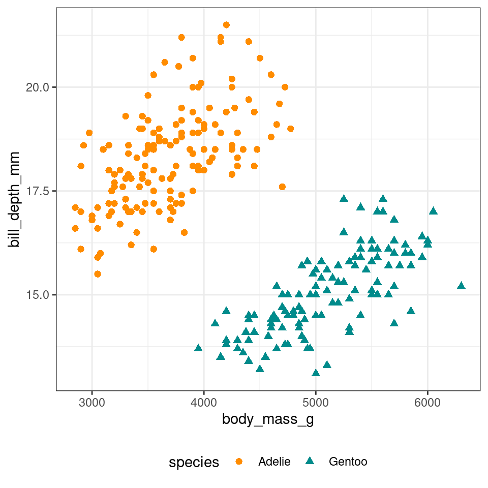

## k-means algorithm

k-mean clusters \(n\) observations (\(x\)) in \(k\) clusters (\(c\)), minimising the within-cluster sum of squares (WCSS)

\[WCSS = \sum_{c=1}^{k} \sum_{x \in c} (x - \overline{x}_c)^2\]

**Algorithm**: `k` observations a randomly selected as initial centroids, then repeat

- **assignment step**: observations assigned to closest centroids
- **update step**: calculate means for each cluster, as new centroid

until centroids don’t change anymore, the algorithm has **converged**

## stats::kmeans

```r
# Execute k-means
bm_bd_clusters <-
  penguins_to_cluster %>%
  dplyr::select(body_mass_g, bill_depth_mm) %>%
  stats::kmeans(
    centers = 2,  # number of clusters (k)
    iter.max = 50 # max number of iterations
  )

# Add clusters to table
penguins_clustered_bm_bd <-
  penguins_to_cluster %>%
  tibble::add_column(
    bm_bd_cluster = bm_bd_clusters %$% cluster
  )
```

## k-means result

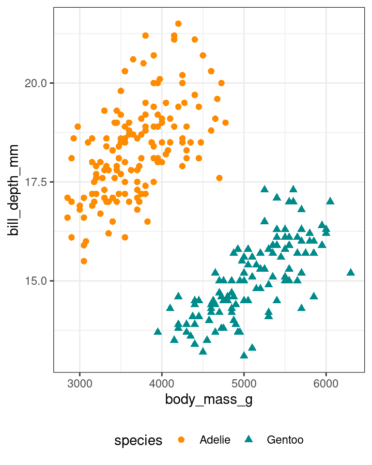

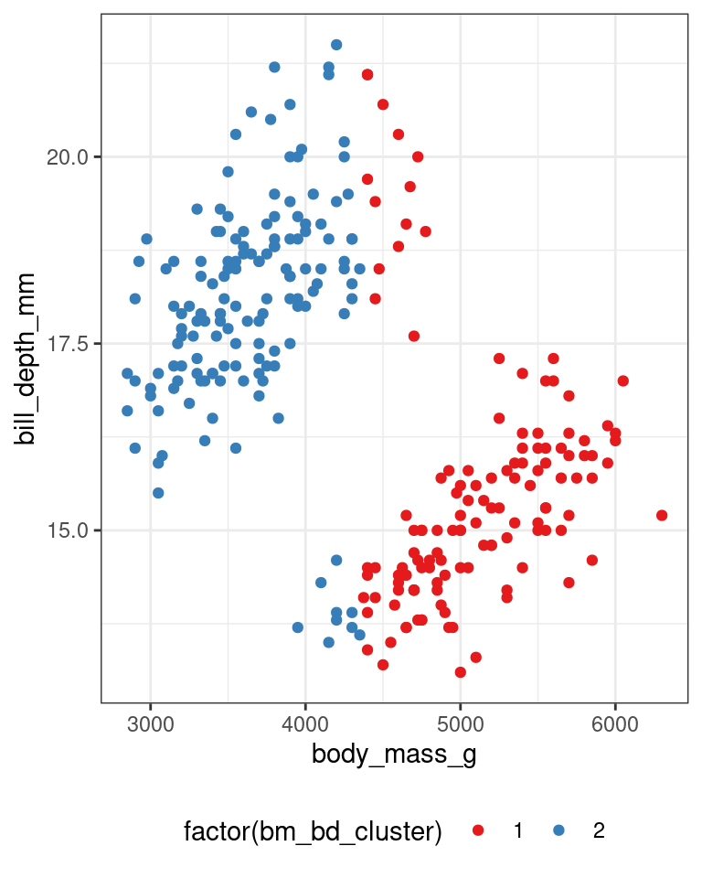

## stats::kmeans

```r
# First, normalise values
penguins_norm <-
  penguins_to_cluster %>%
  dplyr::mutate(
    body_mass_norm = scale(body_mass_g),
    bill_depth_norm = scale(bill_depth_mm)
  )

bm_bd_norm_clusters <-
  penguins_norm %>%
  dplyr::select(body_mass_norm, bill_depth_norm) %>%
  stats::kmeans(centers = 2, iter.max = 50)

penguins_clustered_bm_bd_norm <- penguins_norm %>%
  tibble::add_column(
    bm_bd_cluster = bm_bd_norm_clusters %$% cluster
  )
```

## k-means result

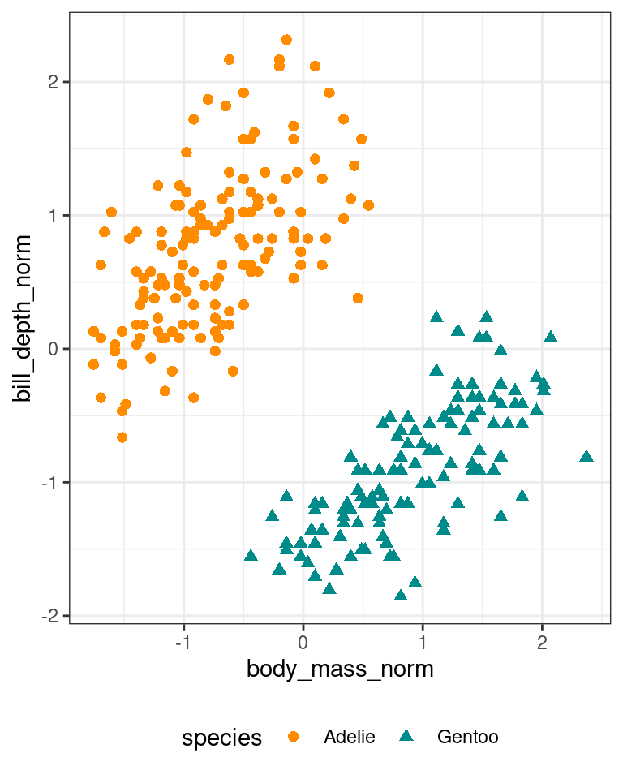

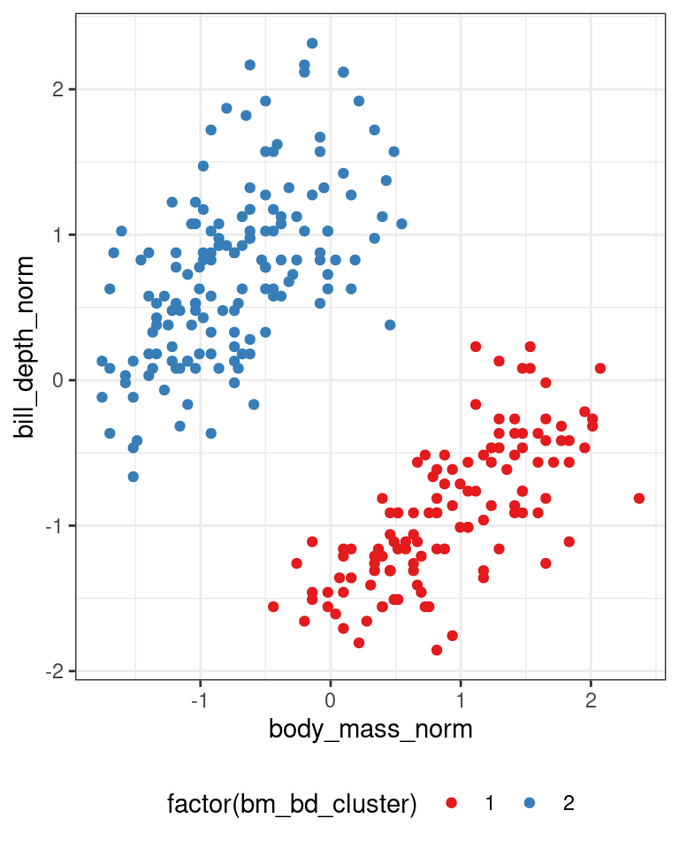

## Limitations

K-means requires to select a fixed number of clusters **in advance**

**Elbow method**:

- calculate clusters for a range of number of clusters
- select the minimum number of clusters that minimises WCSS
- before increasing number of clusters leads minimal benefit

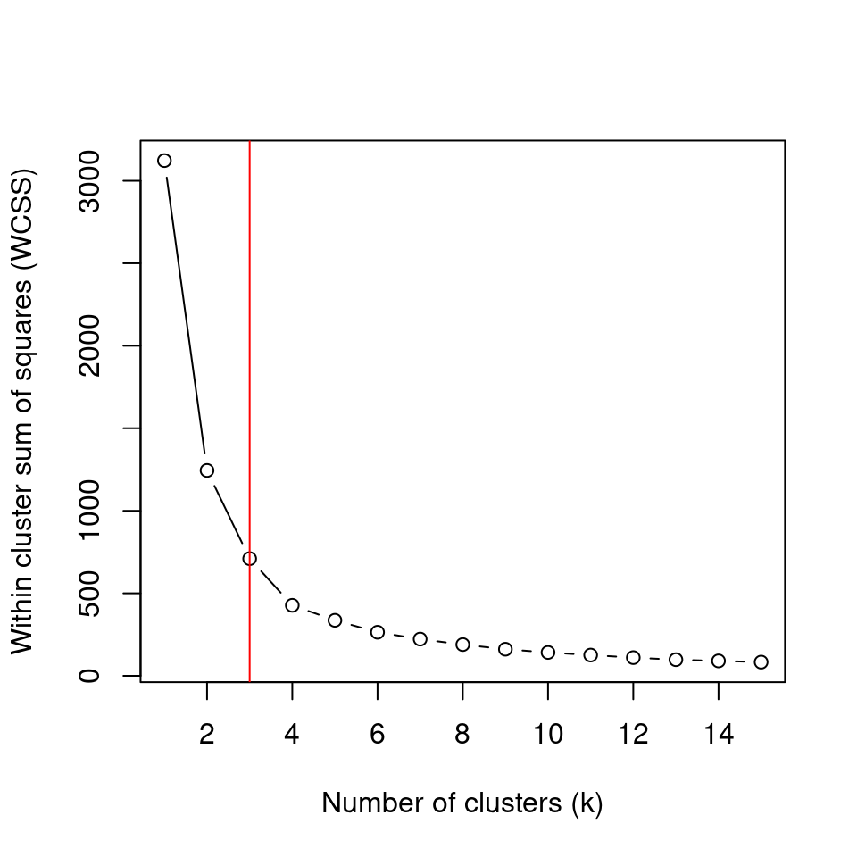

Example for random data  
generated to be in 3 clusters

## Fuzzy c-means

Similar to k-means but allows for *“fuzzy*” membership to clusters

Each observation is assigned with a value per each cluster

- usually from `0` to `1`
- indicates how well the observation fits within the cluster
- i.e., based on the distance from the centroid

```r
library(e1071)

bm_bd_norm_fclusters <- penguins_norm %>%
  dplyr::select(body_mass_norm, bill_depth_norm) %>%
  e1071::cmeans(centers = 2, iter.max = 50)

penguins_clustered_bm_bd_fuzzy <- penguins_norm %>%
  tibble::add_column(bm_bd_fuzzy_cluster = bm_bd_norm_fclusters %$% cluster)
```

## Fuzzy c-means

A *“crisp”* classification can be created by picking the highest membership value.

- that also allows to set a membership threshold (e.g., `0.75`)
- leaving some observations without a cluster

```r
penguins_clustered_bm_bd_fuzzy <-
  penguins_clustered_bm_bd_fuzzy %>%
  tibble::add_column(
    bm_bd_fuzzy_cluster_membership =
      apply(bm_bd_norm_fclusters %$% membership, 1, max)
  ) %>%
  dplyr::mutate(
    bm_bd_crisp_cluster = ifelse(
      bm_bd_fuzzy_cluster_membership < 0.75,
      0, bm_bd_fuzzy_cluster
    )
  )
```

## Fuzzy c-means result

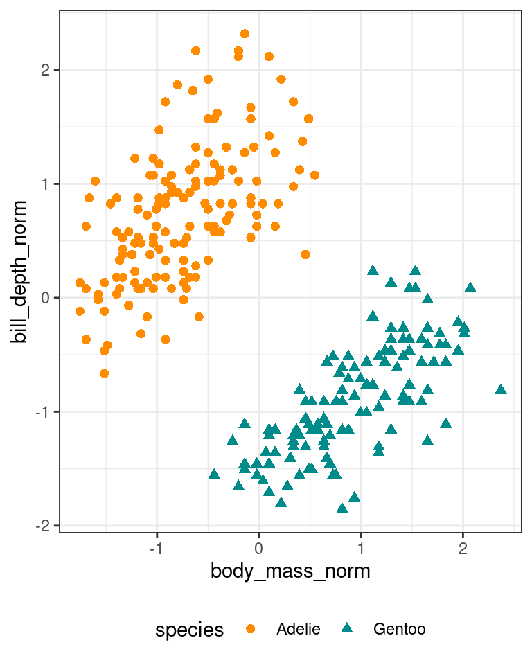

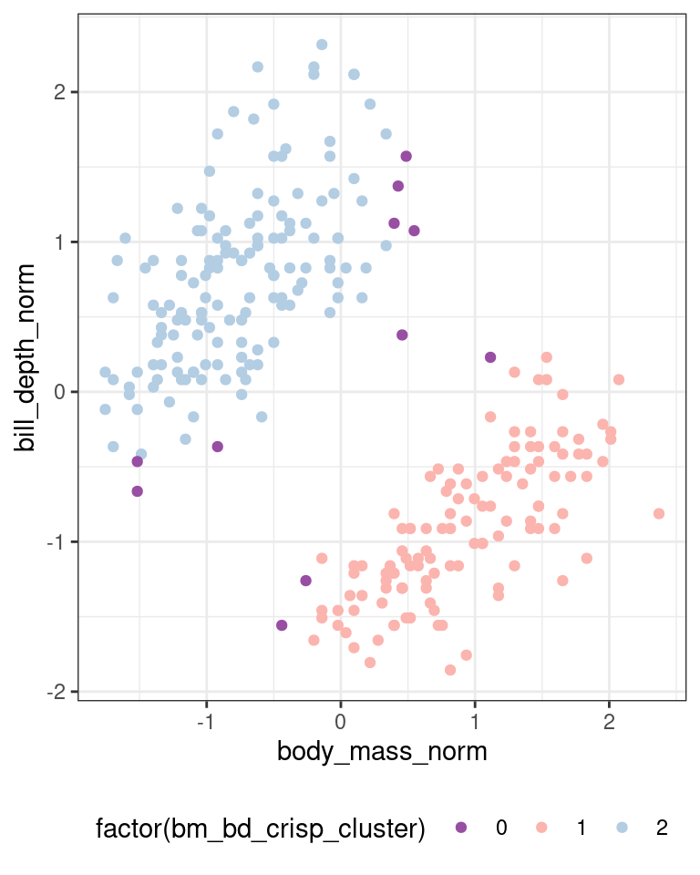

## Geodemographic classifications

In GIScience, clustering is used to create *geodemographic classifications* such as the [2011 Output Area Classification](https://maps.cdrc.ac.uk/#/geodemographics/oac11/default/BTTTFFT/12/-1.1233/52.6454/) from the UK Census 2011 ([Gale *et al.*, 2016](http://josis.net/index.php/josis/article/view/232/150))

- initial set of 167 prospective variables
  - 86 were removed,
  - 41 were retained as they are
  - 40 were combined
  - final set of 60 variables.
- k-means clustering approach to create
  - 8 supergroups
  - 26 groups
  - 76 subgroups

## Summary

Centroid-based clustering

- K-means
- Fuzzy c-means
- Geodemographic classification

**Next**: Hierarchical and density-based clustering

- Hierarchical
- Mixed
- Density-based